# Task2

### 4.3. The “Query” Function (The Core of the Task)

This is the most important step. You will turn one of your `dplyr` queries from **Task 3** into a reusable function.

Look back at your Task 3 code. You probably wrote something like this:

- `my_data |> filter(population > 1000000)`
- `my_data |> filter(planet_type == "Gas Giant")`

That 1000000 or “Gas Giant” is a “magic number” or “magic string”. A function lets you turn it into a parameter.

1. **Choose a query:** Pick one of your `filter()` or `summarise()` queries from Task 3.
2. **Write the function:**
- Give it a descriptive name (e.g., `find_pollution_by_disctrict`, `filter_cities_by_population`).
- It must take at least two arguments: **data** (for the data frame) and a **parameter** for the value you want to change (e.g., `pop_threshold` or `type_name`).
- The function should perform the `dplyr` query and `return` the result.

```r
find_big_capitals <- function(data, pop_threshold) {
  result <- data %>%
    filter(capital == "primary", population > pop_threshold) %>%
    select(city, country, population) %>%
    arrange(desc(population))

  return(result)
}

# Call it (example threshold: 5 million)
big_capitals <- find_big_capitals(my_data, 5000000)
print(big_capitals)
```

```
# A tibble: 32 × 3
   city        country      population
   <chr>       <chr>             <dbl>
 1 Tokyo       Japan          37785000
 2 Jakarta     Indonesia      33756000
 3 Manila      Philippines    24922000
 4 Seoul       Korea, South   23016000
 5 Mexico City Mexico         21804000
 6 Cairo       Egypt          20296000
 7 Dhaka       Bangladesh     19134000
 8 Beijing     China          18522000
 9 Bangkok     Thailand       18007000
10 Moscow      Russia         17332000
# ℹ 22 more rows
```

### 4.4. The “Reporting” Function

Let’s combine everything. Write a single function that calculates several key statistics for a specific **group** or **category** in your data.

1. **Write the function:** Name it `generate_report`. It should take `data` and a `category_name` as arguments (e.g., a specific city, planet type, or region).
2. **Inside the function**:
   - `filter()` your data for only the `category_name` provided.
   - Calculate 3-4 interesting summary statistics (e.g., `mean()`, `max()`, `min()`, `n()`).
   - Use `cat()` to print a nicely formatted “report” to the console.

```r
generate_report <- function(data, country_name) {

  country_data <- data %>%
    filter(country == country_name)

  # Summary statistics
  avg_pop <- mean(country_data$population, na.rm = TRUE)
  max_pop <- max(country_data$population, na.rm = TRUE)
  min_pop <- min(country_data$population, na.rm = TRUE)
  city_count <- nrow(country_data)

  largest_city <- country_data$city[which.max(country_data$population)]
  smallest_city <- country_data$city[which.min(country_data$population)]

  # Print nicely formatted report
  cat("---------------------------------------\n")
  cat("      REPORT FOR:", country_name, "\n")
  cat("---------------------------------------\n")
  cat("Number of cities:", city_count, "\n")
  cat("Average population:", round(avg_pop, 2), "\n")
  cat("Largest city:", largest_city, "(", max_pop, ")\n")
  cat("Smallest city:", smallest_city, "(", min_pop, ")\n")
  cat("---------------------------------------\n\n")
}

# Test your report
generate_report(my_data, "Slovakia")
```

```
---------------------------------------
      REPORT FOR: Slovakia
---------------------------------------
Number of cities: 83
Average population: 32408.29
Largest city: Bratislava ( 475503 )
Smallest city: Sečovce ( 8526 )
---------------------------------------
```

```r
generate_report(my_data, "United States")
```

```
---------------------------------------
      REPORT FOR: United States
---------------------------------------
Number of cities: 5344
Average population: 71000.51
Largest city: New York ( 18832416 )
Smallest city: Montpelier ( 8038 )
---------------------------------------
```

## Task 5. Visualising Your Universe (Base R & ggplot2)

You have found your data (Task 3) and built tools to analyse it (Task 4). Now, you must present your findings to customers.

Your goal is to create four specific visualizations based on the real-world dataset you imported in Task 3.

**Prerequisites:**

- Use the dataset you found and cleaned in Task 3.
- Make sure `library(ggplot2)` is loaded.
- **Crucial:** Every plot must have a **Title**, **x-axis label**, and **y-axis label** that make sense for your specific theme.

```r
# 1 Load libraries
library(ggplot2)
library(dplyr)

# 2 Load dataset
my_df <- read.csv("worldcities.csv", stringsAsFactors = FALSE)

# 3 Create Pop_Ratio (population relative to max)
my_df <- my_df %>%
  mutate(Pop_Ratio = population / max(population, na.rm = TRUE))

# 4 Quick check
head(my_df[, c("city", "country", "population", "Pop_Ratio")])
```

```
       city     country population Pop_Ratio
1     Tokyo       Japan   37785000 1.0000000
2   Jakarta   Indonesia   33756000 0.8933704
3     Delhi       India   32226000 0.8528781
4 Guangzhou       China   26940000 0.7129813
5    Mumbai       India   24973000 0.6609236
6    Manila Philippines   24922000 0.6595739
```

### 5.1. The Quick Sketch (Base R Histogram)

Sometimes you need a quick look at the distribution of your data without loading heavy packages.

1. Choose one **numeric variable** from your dataset (e.g., `price`, `temperature`, `speed`).
2. Use the `hist()` function from base R.
3. Customise the `main` title, `xlab`, and the bar `col` (colour).

**Example:**

```r
# Replace 'your_dataframe' and 'numeric_column' with your actual data
hist(your_dataframe$numeric_column,
     main = "Distribution of [Your Variable]",
     xlab = "[Your Units]",
     col = "lightblue",
     border = "white")
```

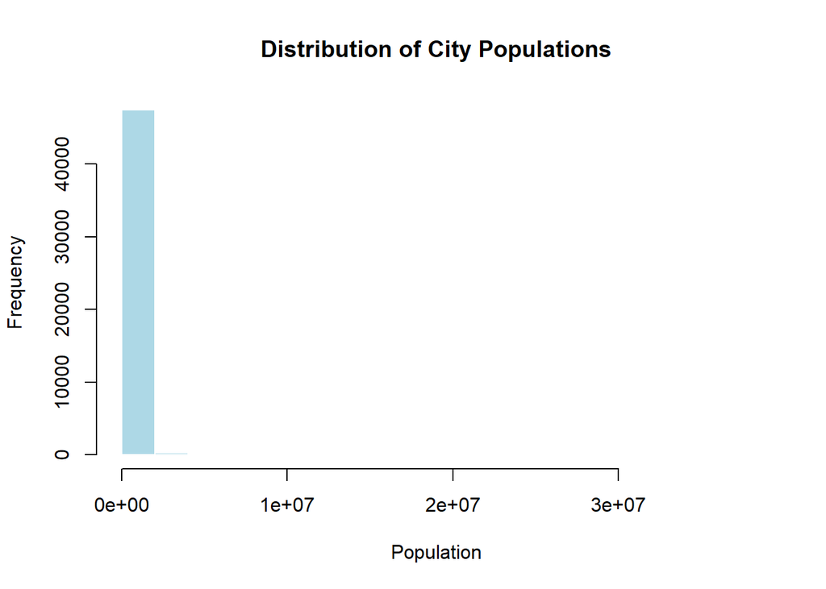

```r
# Histogram of city populations
hist(my_df$population,
     main = "Distribution of City Populations",
     xlab = "Population",
     col = "lightblue",
     border = "white")
```

### 5.2. The Relationship Map (ggplot2 Scatter Plot)

Now, let’s look for patterns using the industry-standard package, **ggplot2**.

1. Choose **two numeric variables** to see if they are correlated.
2. Create a scatter plot using `geom_point()`.
3. Add `geom_smooth()` to add a relationship between variables to the plot.
4. Add `labs()` to rename your axes and title.

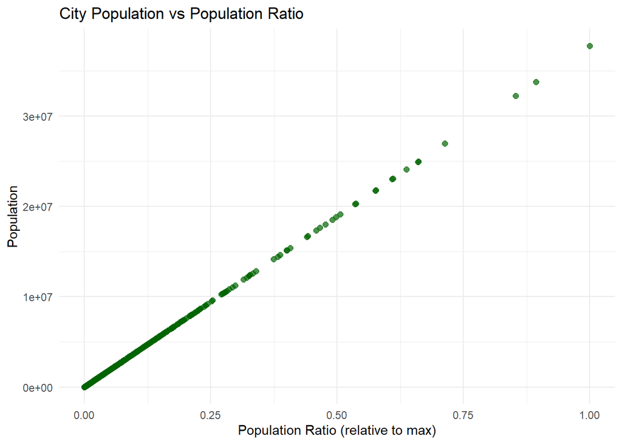

```r
library(ggplot2)

ggplot(my_df, aes(x = Pop_Ratio, y = population)) +
  geom_point(alpha = 0.7, size = 2, color = "darkgreen") +
  geom_smooth(method = "loess", color = "gray") +
  labs(title = "City Population vs Population Ratio",
       x = "Population Ratio (relative to max)",
       y = "Population") +
  theme_minimal()
```